# Text Sentiment Analysis

## Coloring different sentiments

Now to color words according to their sentiment. First recreate the table that has the sentiment counts, using the same procedure as the previous section.

```r
sentiments <- get_sentiments("nrc")
hound_sentiments <- hound %>% inner_join(sentiments) %>% count(word, sentiment, sort=TRUE) %>% pivot_wider(names_from=sentiment, values_from=n, values_fill=0)
```

Now word clouds can be drawn for specific sentiments by picking out specific columns, for example, here are all of the common words associated with “joy”.

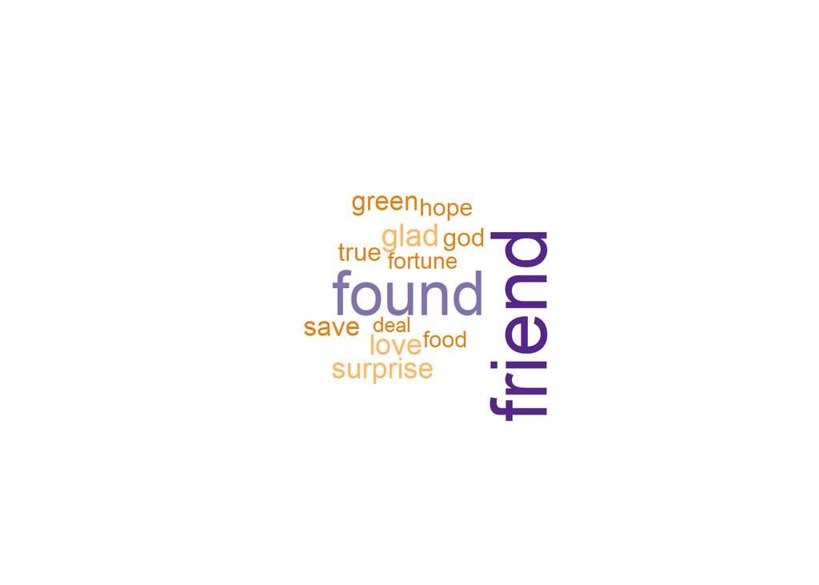

```r
hound_sentiments %>% with(wordcloud(word, joy, min.freq=10, random.color = FALSE, colors = brewer.pal(8, "PuOr")))
```

And here are the common words associated with “fear”.

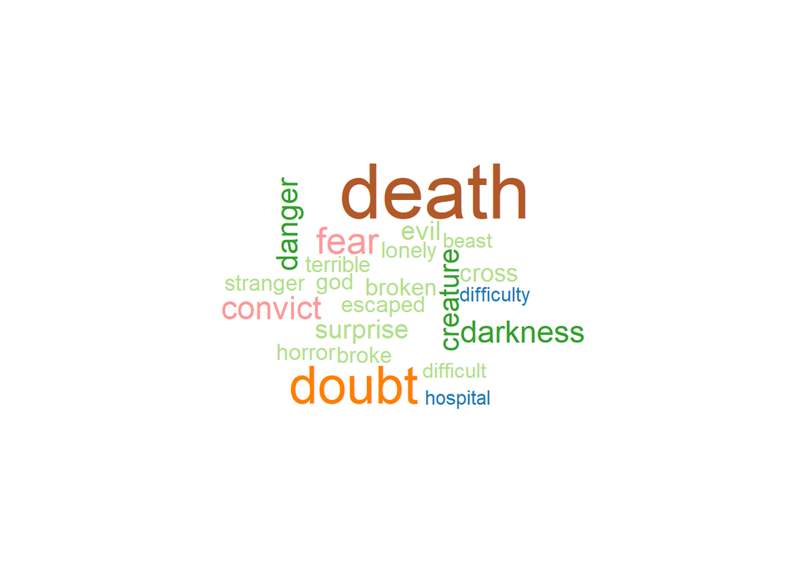

```r
hound_sentiments %>% with(wordcloud(word, fear, min.freq=10, random.color = FALSE, colors = brewer.pal(12, "Paired")))
```